# Memòria anual Salut Mental Perinatal Hospital del Mar

Any 2024

Dani Bergé

2025-01-15

El programa de salut mental perinatal de l’Hospital del Mar es coordina de forma estreta amb els serveis de l’ASSIR de la zona de referència (Sant Martí i Ciutat Vella), tant a nivell dels professionals de ginecologia-obstetricia, llevadors/es i pscicologia, així com amb treball social del servei d’hospitalització d’obstetricia-ginecologia i pediatria. Pot rebre derivacions via correu electrònic ( psiperinatal@hmar.cat ), derivació ordinària entre serveis o derivació ordinària i via IS3 des d’atenció primària.

# Visites ambulatòries

En total s’han programat **141 primeres visites** aquest any 2024, el que suposa un 12.8% més que l’any passat.

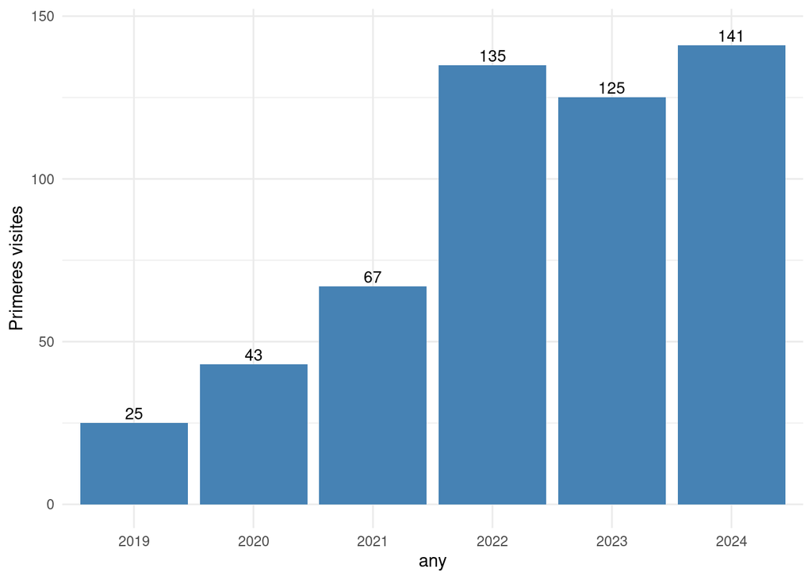

D’aquestes primeres visites, no s’han presentat en primera instància 38 pacients, el que representa un 26.95%, i no s’han presentat en cap intent de citar-les en primera visita durant aquest any 24 pacients, el que suposa un 17.02% del total de primeres visites programades.

Aquesta tendència és similar a la d’altres anys malgrat els esforços dirigits a disminuïr l’absentisme durant aquest any que han estat 1) contacte directe telefònic entre professionals de l’ASSIR i el personal administatiu de programar les visites a salut mental perinatal de l’hospital, 2) obtenció de el dia i hora de la visita al moment en contactar per telèfon, i 3) entrega de tarjetes amb dades de contacte i ubicació del programa.

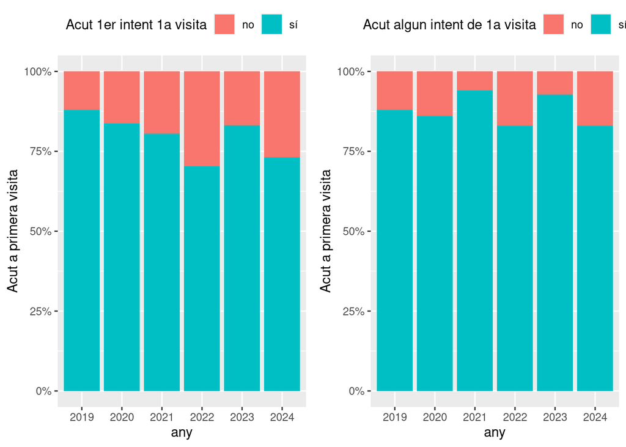

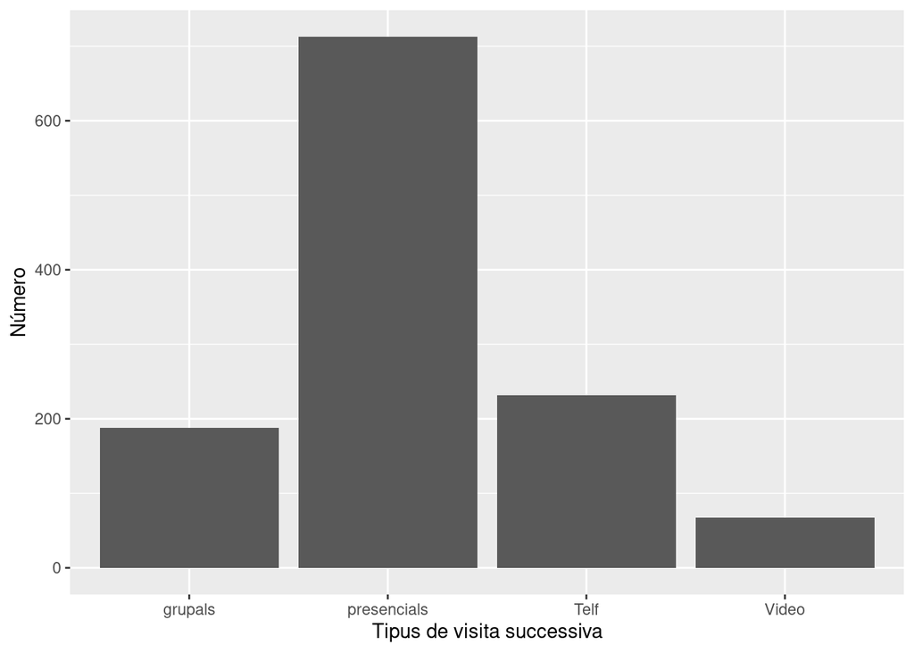

S’han efectuat també **4 edicions de grups terapèutics** amb vocació psico-educativa durant el postaprt, atenent a 32 pacients en aquesta modalitat, el que suposa un total de 188 visites grupals.

# Temps d’espera a 1a visita

Durant l’any 2024, el temps d’espera mitjà desde la derivació a la primera visita programada ha estat de **21.88** dies, amb una desviació de 20.39. En el següent gràfic es pot veure la distribució de l’any actual i dels anteriors.

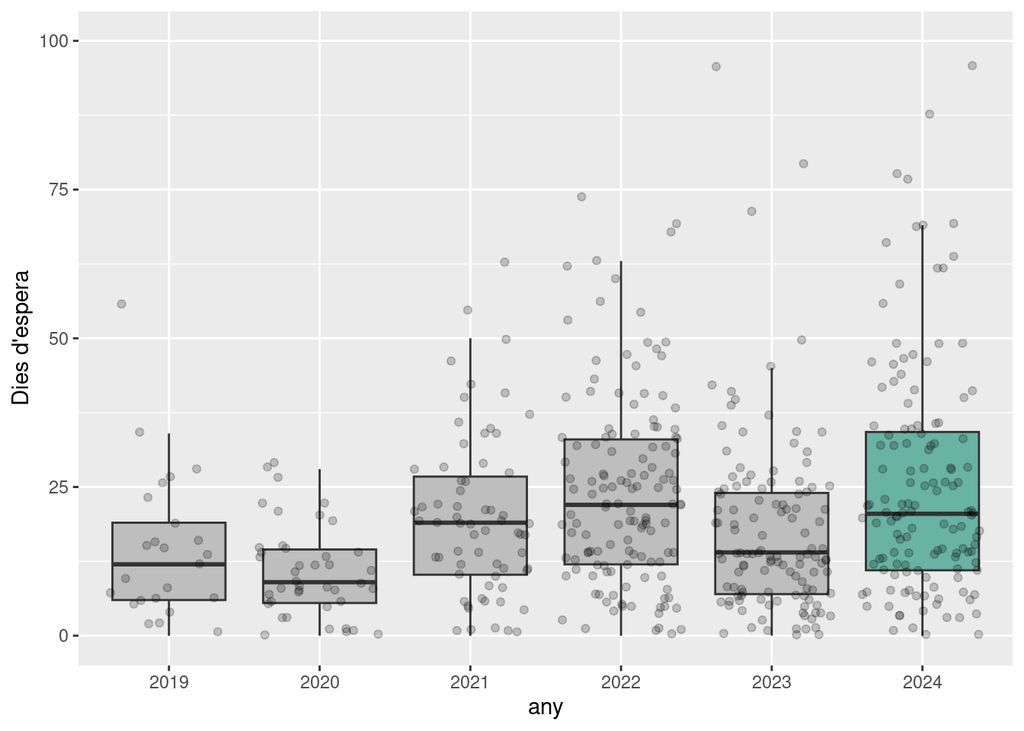

# Procedència de les derivacions

Durant l’any 2024 les principals fonts de derivació ha estat l’ASSIR tal i com es pot veure a la següent gràfica:

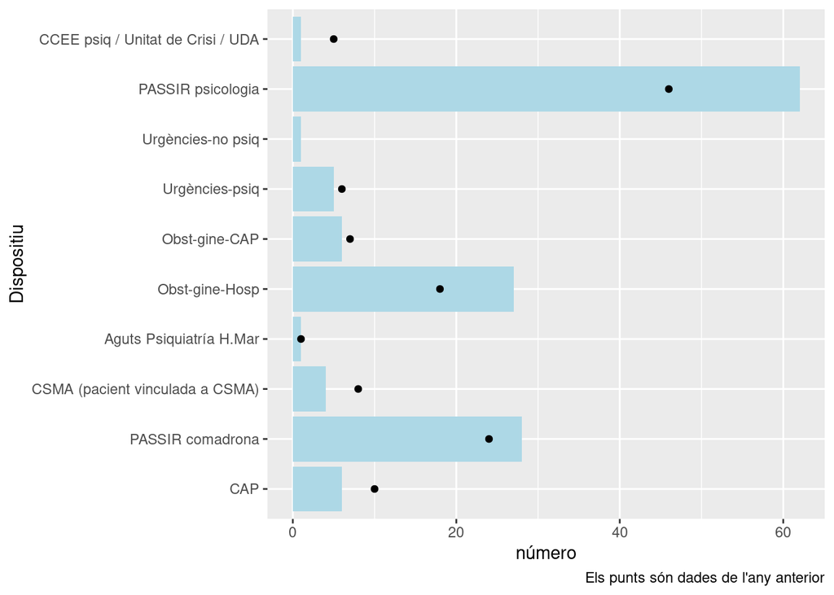

# Motiu de les derivacions

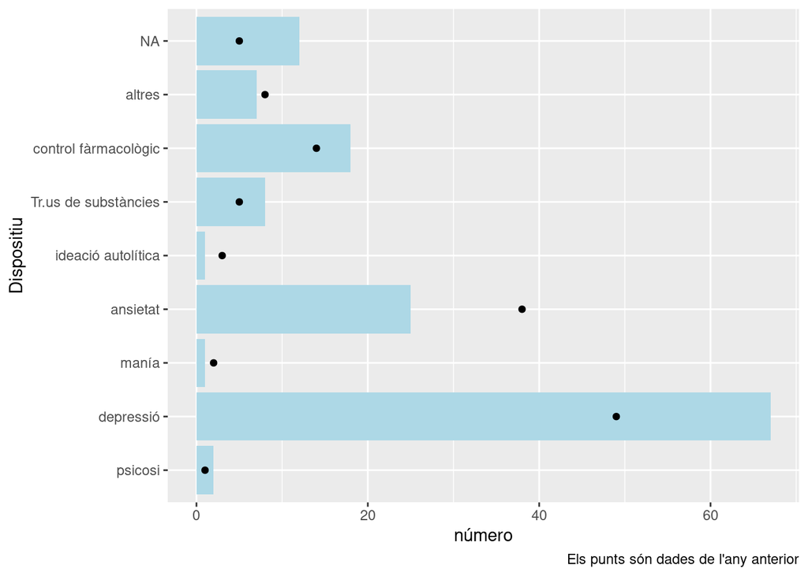

# Característiques de les pacients:

## Estat obstètric inicial

La majoria de derivacions s’efectuen durant la gestació, seguit del periode de postpart, mantenint unes proporcions estables de pre-gestants i interrupcions al llarg dels anys.

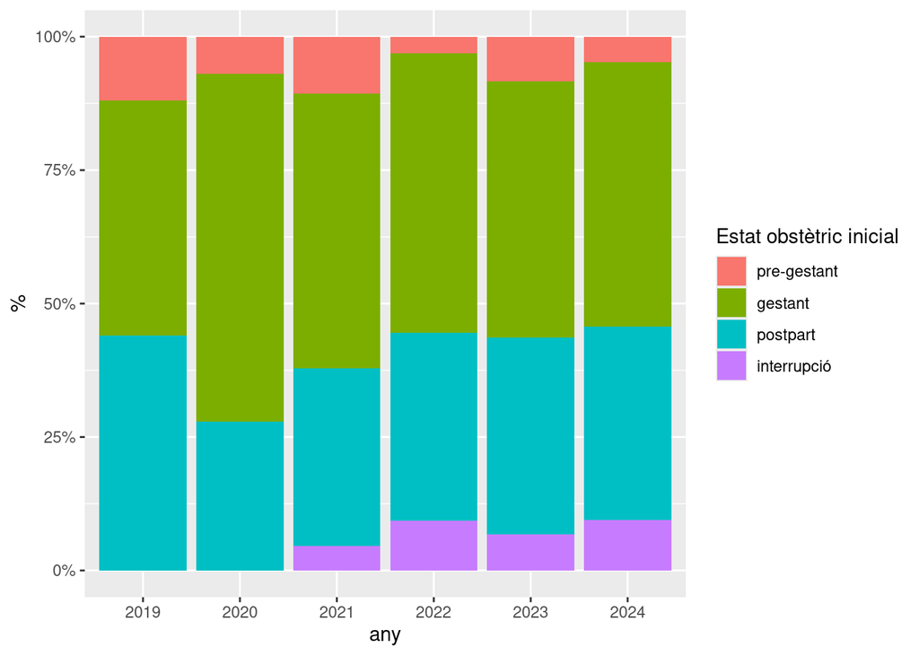

## Setmanes de gestació a la derivació

De les pacients que van ser derivades durant la gestació, la mitja de l’edat gestacional en el moment de la derivació era de 20.63 setmanes, amb una desviació de 9.04.

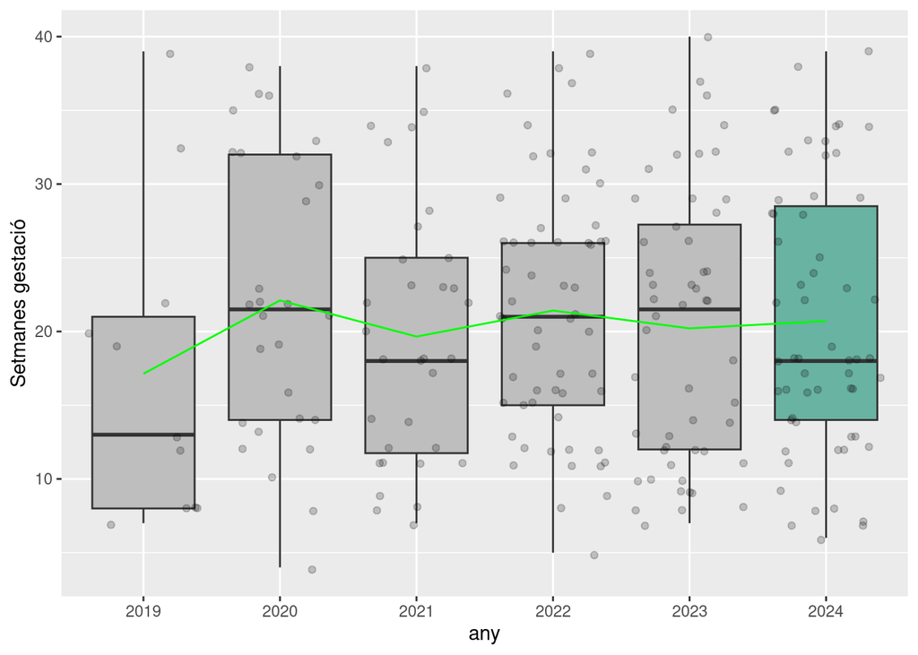

## Setmanes postpart a la derivació

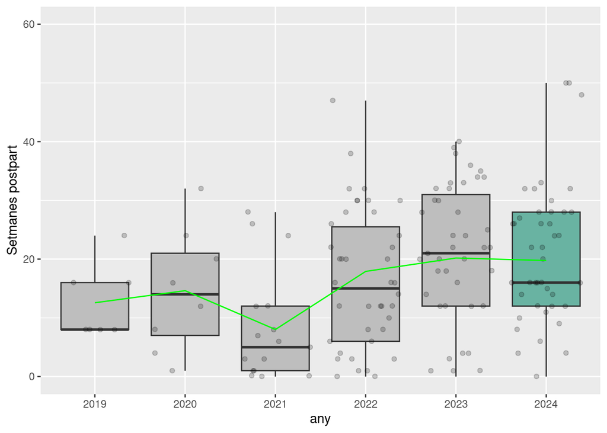

## Edat

L’edat de les pacients quan són derivades en promig és de 33.16 anys, amb una desviació de 6.27

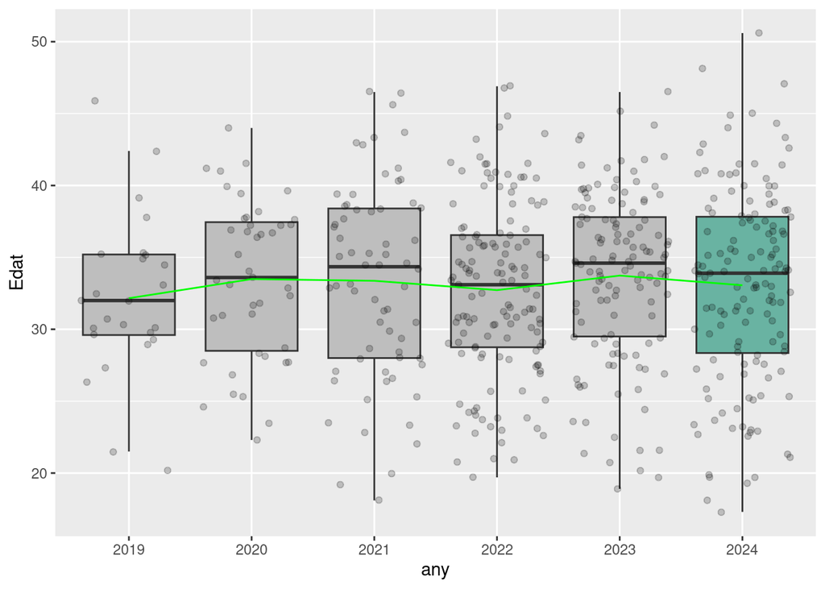

## Ètnia

La majoria de pacients derivades eren caucàssiques, amb un increment en relació a l’any anterior de procedència llatina-hispànica.

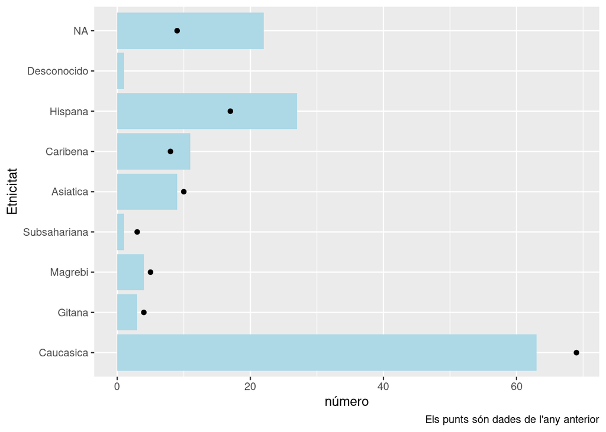

## Nivell educatiu

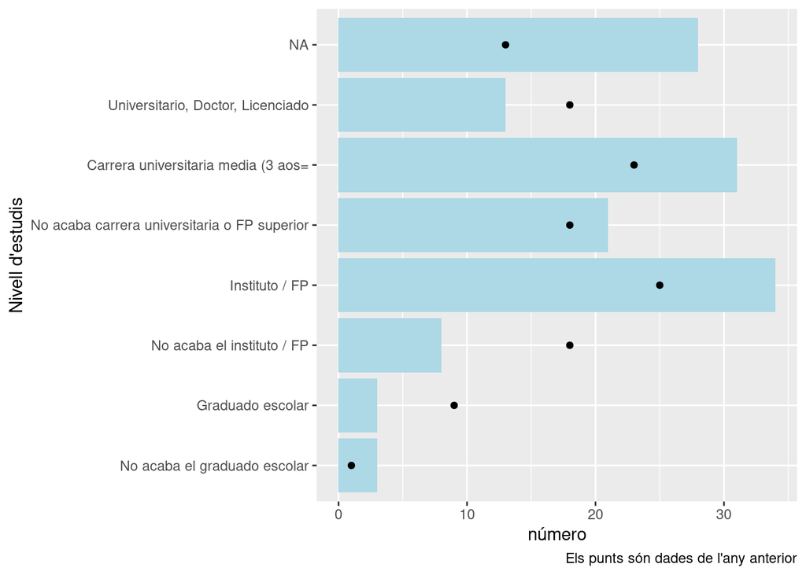

# Objectius 2025

- Disminuïr % No presentats en primeres visites
- Inici visites domiciliàries
- Estructurar coordinació amb EAIAs